# pp4 slides

## Erkennung von Kreditkartenbetrug

##### von Romeo, Marko, Nikola und Miro

```python
# Libraries
import pandas as pd
import numpy as np
import seaborn as sns
import matplotlib.pyplot as plt
import statsmodels.api as sm
import pylab as py
plt.style.use('seaborn-whitegrid')


import seaborn as sns
import matplotlib.pyplot as plt
from scipy import stats

# seaborn graphics settings
sns.set(color_codes=True)

# Ignore warnings
import warnings
warnings.filterwarnings("ignore")
```

### Kontext

#### Datenquelle

[kaggle](https://www.kaggle.com/datasets/dhanushnarayananr/credit-card-fraud) - Das genannte Datenset beschäftigt sich mit der Erkennung von Kreditkartenbetrug und enthält verschiedene Informationen zu vergangenen Transaktionen. Es wurde von einer nicht genannten Institution bereitgestellt.

#### Beschaffung der Daten

Die genaue Beschaffungsquelle für das Datenset wurde nicht angegeben. Es wurde jedoch erwähnt, dass das Datenset von einer nicht genannten Institution bezogen wurde.

#### Problem- und Fragestellung

Problemstellung:

1. Kreditkartenbetrug zu erkennen.

Fragestellung:

1. Wie können wir mithilfe eines Modells Kreditkartenbetrug von legitimen Transaktionen unterscheiden?
2. Welche Merkmale und Muster in vergangenen Transaktionen können verwendet werden, um betrügerische Aktivitäten zu identifizieren?

#### Zielsetzung

Ziel ist es, ein Klassifizierungsmodell zu entwickeln, das auf Basis historischer Transaktionsdaten eine binäre Einschätzung für jede neue Kreditkartenbuchung gibt

#### Vorgehen & Methoden

##### Importing the data

```python
df = pd.read_csv('card_transdata.csv', sep=',', encoding='utf-8')
```

##### Show data types

### Explorative Datenanalyse (EDA)

Daten beschreiben, Identifizierung und Verstehen von Beziehungen und Gruppen,

### Different Datatypes

```python
# Es wird angezeigt um welchen Wert-Typ es sich für die einzelnen Variablen im DataFrame handelt.
df.dtypes
```

```
distance_from_home                float64
distance_from_last_transaction    float64
ratio_to_median_purchase_price    float64
repeat_retailer                   float64
used_chip                         float64
used_pin_number                   float64
online_order                      float64
fraud                             float64
dtype: object
```

### Statistical measures (min, max, std, mean, median, count) for selected variables

```python
# von zwei verschiedenen Daten werden das Minimum, das Maximum, die Standardabweichung, der Median sowie die Anzahl berechnet
# Fraud
print('Fraud:',
      'Count:', round(df.fraud.count(), 1),
      'Min:', round(df.fraud.min(), 1),
      'Max:', round(df.fraud.max(), 1),
      'Mean:', round(df.fraud.mean(), 1),
      'Median:', round(df.fraud.median(), 1),
      'Std:', round(df.fraud.std(), 1))

# distance form home
print('distance from home:',
      'Count:', round(df.distance_from_home.count(), 1),
      'Min:', round(df.distance_from_home.min(), 1),
      'Max:', round(df.distance_from_home.max(), 1),
      'Mean:', round(df.distance_from_home.mean(), 1),
      'Median:', round(df.distance_from_home.median(), 1),
      'Std:', round(df.distance_from_home.std(), 1))
```

```
Fraud: Count: 1000000 Min: 0.0 Max: 1.0 Mean: 0.1 Median: 0.0 Std: 0.3
distance from home: Count: 1000000 Min: 0.0 Max: 10632.7 Mean: 26.6 Median: 10.0 Std: 65.4
```

### Skewness

```python
# die Schiefe der Verteilung für jedes Merkmal im DataFrame wird berechnet
df.skew()
```

```
distance_from_home                 20.239733
distance_from_last_transaction    125.921226
ratio_to_median_purchase_price      8.915015
repeat_retailer                    -2.361310
used_chip                           0.627134
used_pin_number                     2.655457
online_order                       -0.631517
fraud                               2.921824
dtype: float64
```

### Kurtousis

```python
# die Kurtosis (Wölbung) der Verteilung wrid für jedes Merkmal im DataFrame berechnet
df.kurtosis()
```

```
distance_from_home                 1471.615654
distance_from_last_transaction    46979.271728
ratio_to_median_purchase_price      289.503307
repeat_retailer                       3.575791
used_chip                            -1.606706
used_pin_number                       5.051461
online_order                         -1.601190
fraud                                 6.537067
dtype: float64
```

### Extreme values

```python
# Extremwerte die über/unter sein können werden festgelegt
# Long Distance from home
df[df.distance_from_home <= 15].head()
```

|  | distance_from_home | distance_from_last_transaction | ratio_to_median_purchase_price | repeat_retailer | used_chip | used_pin_number | online_order | fraud |
| --- | --- | --- | --- | --- | --- | --- | --- | --- |
| 1 | 10.829943 | 0.175592 | 1.294219 | 1.0 | 0.0 | 0.0 | 0.0 | 0.0 |
| 2 | 5.091079 | 0.805153 | 0.427715 | 1.0 | 0.0 | 0.0 | 1.0 | 0.0 |
| 3 | 2.247564 | 5.600044 | 0.362663 | 1.0 | 1.0 | 0.0 | 1.0 | 0.0 |
| 5 | 5.586408 | 13.261073 | 0.064768 | 1.0 | 0.0 | 0.0 | 0.0 | 0.0 |
| 6 | 3.724019 | 0.956838 | 0.278465 | 1.0 | 0.0 | 0.0 | 1.0 | 0.0 |

```python
# Short distance from last transaction
df[df.distance_from_last_transaction < 0.5].head()
```

|  | distance_from_home | distance_from_last_transaction | ratio_to_median_purchase_price | repeat_retailer | used_chip | used_pin_number | online_order | fraud |
| --- | --- | --- | --- | --- | --- | --- | --- | --- |
| 0 | 57.877857 | 0.311140 | 1.945940 | 1.0 | 1.0 | 0.0 | 0.0 | 0.0 |
| 1 | 10.829943 | 0.175592 | 1.294219 | 1.0 | 0.0 | 0.0 | 0.0 | 0.0 |
| 7 | 4.848247 | 0.320735 | 1.273050 | 1.0 | 0.0 | 1.0 | 0.0 | 0.0 |
| 10 | 14.263530 | 0.158758 | 1.136102 | 1.0 | 1.0 | 0.0 | 1.0 | 0.0 |
| 11 | 13.592368 | 0.240540 | 1.370330 | 1.0 | 1.0 | 0.0 | 1.0 | 0.0 |

## Multivariate non-graphical exploratory data analysis (EDA)

### Cross-tabulation

```python
# erstellt eine Kreuztabelle zwischen den zwei definierten Spalten im DataFrame
# Es ist eine nützliche Methode, um die Beziehung zwischen zwei kategorialen Variablen zu analysieren
pd.crosstab(df['distance_from_home'], df['fraud'])
```

| fraud distance_from_home | 0.0 | 1.0 |
| --- | --- | --- |
| 0.004874 | 1 | 0 |
| 0.021322 | 1 | 0 |
| 0.022599 | 1 | 0 |
| 0.024144 | 1 | 0 |
| 0.024461 | 1 | 0 |
| ... | ... | ... |
| 4601.011222 | 1 | 0 |
| 4823.638452 | 1 | 0 |
| 5797.972589 | 1 | 0 |
| 8777.136420 | 1 | 0 |
| 10632.723672 | 0 | 1 |

1000000 rows × 2 columns

### Pivot tables

```python
# Der Durchschnitt zweier Werte wird genommen und nach einem Dritten Wert gruppiert
# Gut geeignet um Daten beser zu analysieren und verstehen
# Using pivot_table to reshape the data and calculate means
pd.pivot_table(df[['fraud', 'distance_from_home', 'ratio_to_median_purchase_price']],
               index=['fraud'],
               values=['distance_from_home', 'ratio_to_median_purchase_price'],
               aggfunc=np.mean)
```

| fraud | distance_from_home | ratio_to_median_purchase_price |
| --- | --- | --- |
| 0.0 | 22.832976 | 1.423642 |
| 1.0 | 66.261876 | 6.006323 |

## Univariate graphical exploratory data analysis (EDA)

### Histogram (matplotlib)

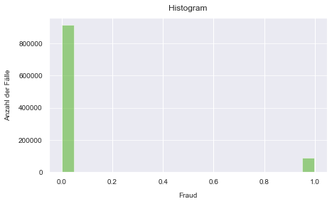

```python
import matplotlib.pyplot as plt
import numpy as np

# Für die definierte Variable wird ein Histogramm erzeugt
# Es ist ein effektiver Weg, um die grundlegende Struktur und die Muster in den Daten zu verstehen
# Sachen wie Streuung, Schiefe und Kurtosis sind ersichtbar
# Plot Histogram
fig = plt.figure( figsize=(7,4))
plt.xticks(fontsize=14, rotation=0)
plt.yticks(fontsize=14, rotation=0)
n, bins, patches = plt.hist(x=df['fraud'],
                            bins=20,
                            color='#42AD12',
                            alpha=0.5,
                            rwidth=0.95
                   )
plt.grid(True)
plt.ticklabel_format(style='plain')
plt.grid(axis='y', alpha=0.75)

# Set labels
plt.xlabel('Fraud', fontsize=10, labelpad=10)
plt.ylabel('Anzahl der Fälle', fontsize=10, labelpad=10)
plt.title('Histogram', fontsize=12, pad=10)

# Set fontsize of tick labels
plt.xticks(fontsize = 10)
plt.yticks(fontsize = 10)

plt.show()
```

### Piechart (matplotlib)

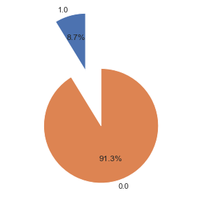

```python
# Stellt in einem Kuchendiagramm die Verteilung der Werte einer Variable an
df_bar = df.fraud.value_counts().nlargest(8).sort_values(ascending=True)

# Simple bar chart
sizes = list(df_bar.values)
labels = list(df_bar.index.values)
explode = (0,1) # increases distance of pieces

fig1, ax1 = plt.subplots(figsize=(5,5))
ax1.pie(sizes,
        labels=labels,
        explode=explode,
        autopct='%1.1f%%',
        shadow=False,
        startangle=90)
ax1.axis('equal')  # ensures that pie is drawn as a circle.

plt.show()
```

## Multivariate graphical exploratory data analysis (EDA)

### Scatterplot (matplotlib)

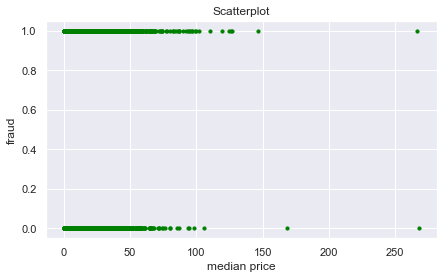

```python
# erstellt ein Scatterplot, das die Beziehung zwischen zwei bestimmten Variablen im DataFrame darstellt
# kann nützlich sein, um Muster, Trends oder Ausreißer in den Daten zu erkennen
plt.figure(figsize=(7,4))
plt.scatter(df['ratio_to_median_purchase_price'],
           df['fraud'],
           color="green",
           alpha=1.0,
           s=10)
plt.title('Scatterplot', fontsize=12)
plt.xlabel('median price')
plt.ylabel('fraud')
plt.show()
```

### Scatterplot der mehrere Merkmale visualisiert

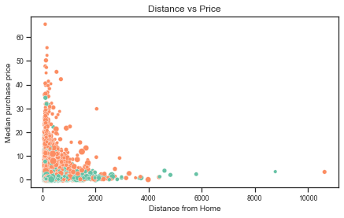

```python
# Farbe bestimmt ob es sich um einen Betrugsfall handelt
# Bubble grösse bestimmt wie lange die Transaktion her ist
# Subset of df
df_sub = df.loc[(df['distance_from_home'] >= 100) & (df['distance_from_last_transaction'] <= 5)]

plt.figure(figsize=(7,4))
plt.ticklabel_format(style='plain')
cmap = sns.cubehelix_palette(dark=.3, light=3, as_cmap=True)

ax = sns.scatterplot(x="distance_from_home",
                     y="ratio_to_median_purchase_price",
                     size="distance_from_last_transaction", # determines bubble size
                     hue="fraud",  # determines color
                     palette="Set2",
                     data=df_sub)

# Set title and axes
ax.set_title('Distance vs Price', fontsize = 12)
ax.set_xlabel('Distance from Home', fontsize = 10)
ax.set_ylabel('Median purchase price', fontsize = 10)
ax.legend([],[], frameon=False) # skip legend
```

### Unifying & Tranformation (Marko)

Datentypen und Formate analysieren und bei Bedarf vereinheitlichen, Daten sinnvoll zusammenführen

```python
# Generelle Informationen zum Dataframe
df.info()

# Nur die Datentypen anzeigen für Analyse
df.dtypes
```

```
<class 'pandas.core.frame.DataFrame'>
RangeIndex: 1000000 entries, 0 to 999999
Data columns (total 9 columns):
 #   Column                          Non-Null Count    Dtype
---  ------                          --------------    -----
 0   distance_from_home              1000000 non-null  float64
 1   distance_from_last_transaction  1000000 non-null  float64
 2   ratio_to_median_purchase_price  1000000 non-null  float64
 3   repeat_retailer                 1000000 non-null  float64
 4   used_chip                       1000000 non-null  float64
 5   used_pin_number                 1000000 non-null  float64
 6   online_order                    1000000 non-null  float64
 7   fraud                           1000000 non-null  float64
 8   var                             1000000 non-null  float64
dtypes: float64(9)
memory usage: 68.7 MB
```

```
distance_from_home                float64
distance_from_last_transaction    float64
ratio_to_median_purchase_price    float64
repeat_retailer                   float64
used_chip                         float64
used_pin_number                   float64
online_order                      float64
fraud                             float64
var                               float64
dtype: object
```

### Transformation

Alle Daten besitzen den Datentyp float64. Wir haben hier das Glück bei dem Datensatz von Kaggle, dass wir keine Transformation der Datentypen benötigen. Das Format float64 ist bereits für unser Projekt geeignet.

### Unifying

Wir verwenden in unserem Projekt nur einen Datensatz vom Kaggle. Dieser Datensatz hat bereit geeignete Formate und Spalten definiert, die wir später für die Features (erklärenden Variablen) nutzen können. Deshalb benötigen wir keine Vereinheitlichung der Formate. Da wir nicht mehrere Datensätze verwenden, müssen wir die Daten nicht zusammenführen, da alle relevanten Datensätze bereits enthalten sind. Deshalb verwenden wir kein Concatenate, Append, Join, Merge oder Aggregate.

### Data Cleansing (Romeo)

Beurteilung der Datenqualität und erforderliche Bereinigung der Daten

```python
# Remove duplicates
df = df.drop_duplicates()
df.head(5)

# Remove missing values
# There were no na values
df = df.dropna()
df.head(5)
```

|  | distance_from_home | distance_from_last_transaction | ratio_to_median_purchase_price | repeat_retailer | used_chip | used_pin_number | online_order | fraud | var |
| --- | --- | --- | --- | --- | --- | --- | --- | --- | --- |
| 0 | 57.877857 | 0.311140 | 1.945940 | 1.0 | 1.0 | 0.0 | 0.0 | 0.0 | 0.043491 |
| 1 | 10.829943 | 0.175592 | 1.294219 | 1.0 | 0.0 | 0.0 | 0.0 | 0.0 | -0.189300 |
| 2 | 5.091079 | 0.805153 | 0.427715 | 1.0 | 0.0 | 0.0 | 1.0 | 0.0 | -0.498812 |
| 3 | 2.247564 | 5.600044 | 0.362663 | 1.0 | 1.0 | 0.0 | 1.0 | 0.0 | -0.522048 |
| 4 | 44.190936 | 0.566486 | 2.222767 | 1.0 | 1.0 | 0.0 | 1.0 | 0.0 | 0.142373 |

```
Count of rows:  39835
```

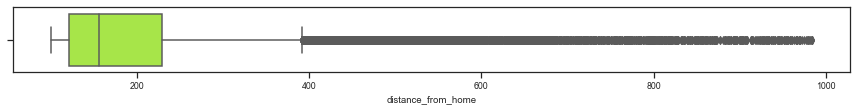

```python
# Remove outliers from distance_from_home
q_low = df_sub["distance_from_home"].quantile(0.01)
q_hi  = df_sub["distance_from_home"].quantile(0.99)

df_filtered = df_sub[(df_sub["distance_from_home"] < q_hi) & (df_sub["distance_from_home"] > q_low)]

plt.figure(figsize=(15,1.2))
plt.ticklabel_format(style='plain')
sns.boxplot(x=df_filtered['distance_from_home'], color="greenyellow")
print("Count of rows: ", len(df_filtered))
```

```
Count of rows:  39037
```

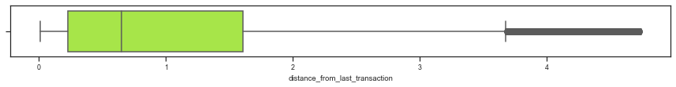

```python
# Remove outliers from distance_from_last_transaction
q_low = df_filtered["distance_from_last_transaction"].quantile(0.01)
q_hi  = df_filtered["distance_from_last_transaction"].quantile(0.99)

df_filtered = df_filtered[(df_filtered["distance_from_last_transaction"] < q_hi) & (df_filtered["distance_from_last_transaction"] > q_low)]

plt.figure(figsize=(15,1.2))
plt.ticklabel_format(style='plain')
sns.boxplot(x=df_filtered['distance_from_last_transaction'], color="greenyellow")
print("Count of rows: ", len(df_filtered))
```

```
Count of rows:  38255
```

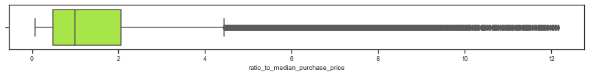

```python
# Remove outliers from distance_from_last_transaction
q_low = df_filtered["ratio_to_median_purchase_price"].quantile(0.01)
q_hi  = df_filtered["ratio_to_median_purchase_price"].quantile(0.99)

df_filtered = df_filtered[(df_filtered["ratio_to_median_purchase_price"] < q_hi) & (df_filtered["ratio_to_median_purchase_price"] > q_low)]

plt.figure(figsize=(15,1.2))
plt.ticklabel_format(style='plain')
sns.boxplot(x=df_filtered['ratio_to_median_purchase_price'], color="greenyellow")
print("Count of rows: ", len(df_filtered))
```

```python
df = df_filtered
df
```

|  | distance_from_home | distance_from_last_transaction | ratio_to_median_purchase_price | repeat_retailer | used_chip | used_pin_number | online_order | fraud | var |
| --- | --- | --- | --- | --- | --- | --- | --- | --- | --- |
| 12 | 765.282559 | 0.371562 | 0.551245 | 1.0 | 1.0 | 0.0 | 0.0 | 0.0 | -0.454687 |
| 15 | 179.665148 | 0.120920 | 0.535640 | 1.0 | 1.0 | 1.0 | 1.0 | 0.0 | -0.460261 |
| 16 | 114.519789 | 0.707003 | 0.516990 | 1.0 | 0.0 | 0.0 | 0.0 | 0.0 | -0.466923 |
| 37 | 202.757442 | 0.275015 | 0.775549 | 1.0 | 0.0 | 1.0 | 1.0 | 0.0 | -0.374567 |
| 112 | 335.189320 | 1.114168 | 0.098243 | 1.0 | 0.0 | 0.0 | 1.0 | 1.0 | -0.616497 |
| ... | ... | ... | ... | ... | ... | ... | ... | ... | ... |
| 999903 | 241.832872 | 2.390563 | 1.079446 | 1.0 | 1.0 | 0.0 | 1.0 | 0.0 | -0.266016 |
| 999916 | 167.139756 | 0.282253 | 0.308468 | 1.0 | 0.0 | 0.0 | 1.0 | 1.0 | -0.541406 |
| 999924 | 108.428315 | 0.050380 | 0.595808 | 1.0 | 0.0 | 0.0 | 0.0 | 0.0 | -0.438769 |
| 999941 | 142.526517 | 0.224511 | 0.368224 | 1.0 | 1.0 | 0.0 | 1.0 | 0.0 | -0.520061 |
| 999961 | 337.291331 | 4.606990 | 0.181799 | 1.0 | 1.0 | 0.0 | 1.0 | 0.0 | -0.586652 |

38255 rows × 9 columns